# Diagrams

Anthony Davidson

2019-10-14

# 1 Examples

Here are a collection of diagrams that have extended explainations (in time) within the pages.

# 2 Introduction

Conceptial diagrams are vital for understanding processes and developing incremetal science, however, there seems to be very few packages or other software that aligns with the literature in how and when these diagrams should be developed.

This book uses `R` and the core packages [`diagrammeR`](https://cran.r-project.org/web/packages/DiagrammeR/index.html).

There is a great resource written by the author [here](https://rich-iannone.github.io/DiagrammeR/index.html) but I am still working out overall how the package in R works. - A good explaination of the features [here](https://rich-iannone.github.io/DiagrammeR/index.html#features)

## 2.1 Resources

The general concept of the package I am using is very simple but the code looks intemidating:

```r
grViz("
digraph boxes_and_circles {

  # a 'graph' statement
  graph [overlap = true, fontsize = 10]

  # several 'node' statements
  node [shape = box,
        fontname = Helvetica]
  'box'; 'shape'

  node [shape = circle,
        fixedsize = true,
        width = 0.9] // sets as circles
  'shape2'; 'circles'

  node [shape = circle,
        fixedsize = true,
        width = 0.9] // sets as circles
  'join'; 'arrow'

  # several 'edge' statements
  join->arrow
}
")
```

[interactive chart not shown]

## 2.2 My notes

For example, you might like to think of a simple statistical regression with a single `y` and `x`as:

$$y_i = \beta_0 + \beta_1(x_i) + error_i$$
And if this was to be diagramatically represented it could be describled like so with the following descriptions:

*1:* We are proposing that $y_i$ is directly effected by $x_i$.

[interactive chart not shown]

### 2.2.1 Examples

This info I think is interesting but haven’t investigated it much yet.

### 2.2.2 Math insert

Here is an example of inserting math equations into `diagrammeR` using mathJax??

```
##
## > library(DiagrammeR)
##
## > add_mathjax(grViz("\ndigraph G {\n  A [label=\"$\\\\cos (2\\\\theta) = \\\\cos^2 \\\\theta - \\\\sin^2 \\\\theta$\"];\n  A -> B;\n}\n"))
```

### 2.2.3 Kol but not working

### 2.2.4 Mixed models

Mixed models essentially start with sample mean differences between groups and then add additional complexity in favour of poor fitting models.

You can write out models and variable relationships using statistical equations such as:

For example you might think that generally individuals that …

$$outcome = \beta_0 + \beta_1(sex_i) + \beta(age_i) + error_i$$

# 3 Software and Hardware

This is a great question I have been playing around with to help learn how to use the `diagrammeR` package. The question is:  
**What is the difference between software and hardware?**

I thought that is was an obvious difference. Hardware is the stuff that makes the software work.

For example, `RAM` is hardware, `word` is software?

| Software | Hardware |
| --- | --- |
| R | RAM |
| word | CPU |
| excel | Processors |

## 3.1 Software

But the problem is when somebody knows the interface (software that uses many types of software). Examples of this are programs like `RStudio`, `vs-code` and other such programs. This is because they are a single piece of software that uses “heaps” of other software.

[interactive chart not shown]

But then each bit of software such as `GIT` and `R` can be accessed by many different types of software…so is `R` not just hardware then?

[interactive chart not shown]

And now the question becomes about the definition of what software and hardware are…

| Software | Hardware |
| --- | --- |
| R | RAM |
| word | CPU |
| excel | Processors |

### 3.1.1 RStudio

But the problem is when somebody knows the interface (software that uses many types of software). Examples of this are programs like `RStudio`, `vs-code` and other such programs. This is because they are a single piece of software that uses “heaps” of other software.

[interactive chart not shown]

### 3.1.2 ‘vs-code’

But then each bit of software such as `GIT` and `R` can be accessed by many different types of software…so is `R` not just hardware then?

[interactive chart not shown]

### 3.1.3 R

[interactive chart not shown]

## 3.2 Computer processes

### 3.2.1 RStudio

This is an example of a piece of software. It needs your computer (hardware) to run so therefore it is software. Just the same as `R`….but not really.

#### 3.2.1.1 A simple `Rscript`

[interactive chart not shown]

But this is not really what is happening. For example this is the `RMarkdown` figure for this process:

[interactive chart not shown]

### 3.2.2 v3

[interactive chart not shown]

### 3.2.3 v4

[interactive chart not shown]

# 4 Interacting Species

To build diagrams that accounts for the issues and nature of data collection as well as incorperating the life history constrains of the species being modelled.

- Examples

## 4.1 Three species models

### 4.1.1 v1

[interactive chart not shown]

### 4.1.2 v2

[interactive chart not shown]

# 5 Likert Scales

## 5.1 The problem

To build a sampling design that accounts for the issues and nature of data collection of foriegn bank movements using person-to-person == surveys.

## 5.2 Method

Here we want to address the key objectives of our reseach by collecting data in an unbias and representative way. To understand the true underlying trends in the data a pilot study with a large enough sample is explored below.

Here we have a difficult question to address due to the bias in the data capture method. This is really interesting and challenging from a statistical prospective. This is also a problem that the qualitative approach fails to address (waiting to see what others say about this..?)

Here is a step-by-step to approach to this research in a quantativite way:

1. The questions are grouped into sets of questions that all address a general objective or question the research has. We can first see if these patterns are true for the responses. These are as follows:

[interactive chart not shown]

There are several issues with this because the data collected is often non-normal and needs to be transformed. The first step however is to simply visualise the data in a way that we will also be fitting the statistical models.

[interactive chart not shown]

There is some simple dataset transformations that can be done to make it easier to work with the data in the plotting functions.

[interactive chart not shown]

## 5.3 Flow diagram

Here I think we should add the relationship to each question and the proposed hypothesis…

### 5.3.1 v1

[interactive chart not shown]

### 5.3.2 v2

A similar automatic report can be generated using by using the DIY_ANOVA app [here](https://pecostats.shinyapps.io/DIY_ANOVA/). It consists of a reduced version of the following report and sections.

[interactive chart not shown]

### 5.3.3 v3

[interactive chart not shown]

### 5.3.4 v4

[interactive chart not shown]

# 6 Mixed regression models

## 6.1 Models

Mixed models essentially start with sample mean differences between groups and then add additional complexity in favour of poor fitting models.

You can write out models and variable relationships using statistical equations such as $y_i = \beta_0 + \beta_1(x_i)$ where the variables can be collected either through direct questions or transformed data from the orginal questions. What does it look like in a diagram explaining how the variables are proposed to be similar? Example below:

### 6.1.1 Constant only

$$outcome = \beta_0$$

[interactive chart not shown]

### 6.1.2 Single predictor

$$outcome = \beta_0 + \beta_1(sex_i)$$

[interactive chart not shown]

### 6.1.3 Multi-level v1

For example you might think that generally individuals that …

$$outcome = \beta_0 + \beta_1(sex_i) + \beta(age_i) + error_i$$

[interactive chart not shown]

### 6.1.4 Multi-level v2

For example you might think that generally individuals that …

$$outcome = \beta_0 + \beta_1(sex_i) + \beta(age_i) + error_i$$

[interactive chart not shown]

# 7 NZ Beech Forests

The first beech forest paper assumes and tests the following process:

$$log(N) = Control + Valley + Rats + Control:Rats$$
$$r_{j,t} = \beta_{0,s,v,c} + \beta_{1,s,v,c} (S_{j,t})+ \beta_{2,s,v,c} (N_{j,t-1}) + \beta_{3,s,v,c} (R_{j,t-1})$$

## 7.1 Draft ideas

### 7.1.1 v1

[interactive chart not shown]

### 7.1.2 v2

[interactive chart not shown]

### 7.1.3 v3

[interactive chart not shown]

# 8 NZ Beech Forests

$$log(N) = Control + Valley + Rats + Control:Rats$$
$$r_{j,t} = \beta_{0,s,v,c} + \beta_{1,s,v,c} (S_{j,t})+ \beta_{2,s,v,c} (N_{j,t-1}) + \beta_{3,s,v,c} (R_{j,t-1})$$

The first beech forest paper assumes and tests the following model.

## 8.1 Draft ideas

### 8.1.1 v1

[interactive chart not shown]

### 8.1.2 v2

[interactive chart not shown]

### 8.1.3 v3

[interactive chart not shown]

## 8.2 Draft processes

### 8.2.1 Mice

### 8.2.2 Mice and Rats

### 8.2.3 Mice, rats and possums

### 8.2.4 Mice, rats, possums and stoats

# 9 Node and Edge Data Frames

Figures and tables with captions will be placed in `figure` and `table` environments, respectively.

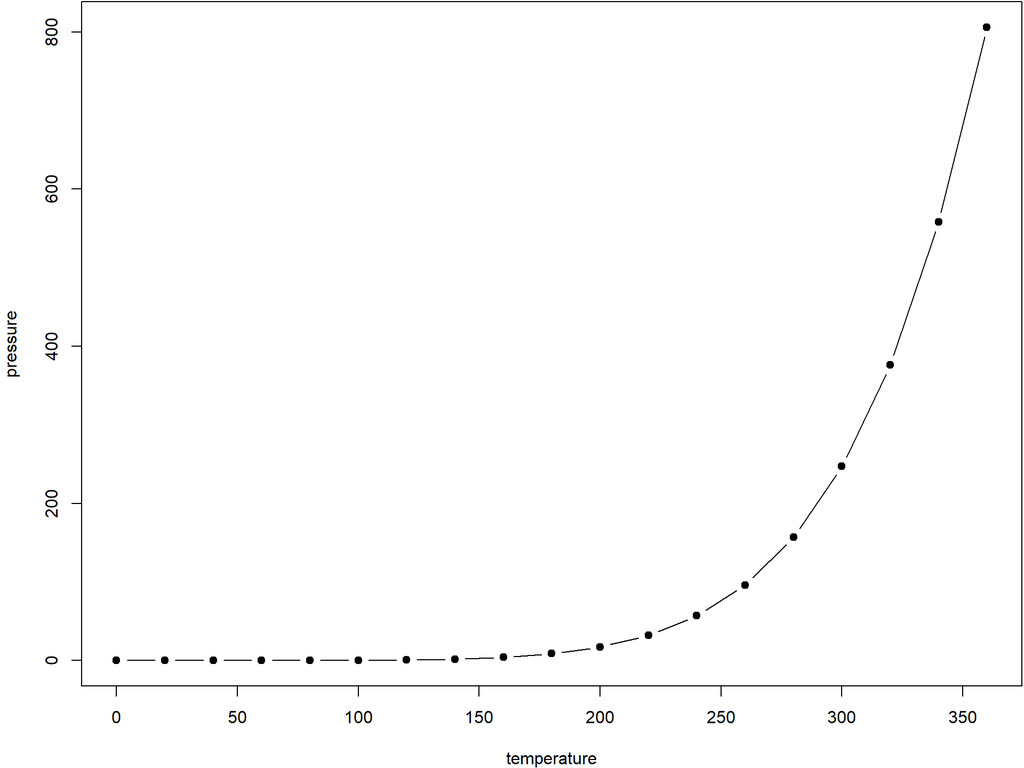

Figure 9.1: Here is a nice figure!

Reference a figure by its code chunk label with the `fig:` prefix, e.g., see Figure 9.1. Similarly, you can reference tables generated from `knitr::kable()`, e.g., see Table 9.1.

Table 9.1: Here is a nice table!

| Sepal.Length | Sepal.Width | Petal.Length | Petal.Width | Species |
| --- | --- | --- | --- | --- |
| 5.1 | 3.5 | 1.4 | 0.2 | setosa |
| 4.9 | 3.0 | 1.4 | 0.2 | setosa |
| 4.7 | 3.2 | 1.3 | 0.2 | setosa |
| 4.6 | 3.1 | 1.5 | 0.2 | setosa |
| 5.0 | 3.6 | 1.4 | 0.2 | setosa |
| 5.4 | 3.9 | 1.7 | 0.4 | setosa |
| 4.6 | 3.4 | 1.4 | 0.3 | setosa |
| 5.0 | 3.4 | 1.5 | 0.2 | setosa |
| 4.4 | 2.9 | 1.4 | 0.2 | setosa |
| 4.9 | 3.1 | 1.5 | 0.1 | setosa |
| 5.4 | 3.7 | 1.5 | 0.2 | setosa |
| 4.8 | 3.4 | 1.6 | 0.2 | setosa |
| 4.8 | 3.0 | 1.4 | 0.1 | setosa |
| 4.3 | 3.0 | 1.1 | 0.1 | setosa |
| 5.8 | 4.0 | 1.2 | 0.2 | setosa |
| 5.7 | 4.4 | 1.5 | 0.4 | setosa |
| 5.4 | 3.9 | 1.3 | 0.4 | setosa |
| 5.1 | 3.5 | 1.4 | 0.3 | setosa |
| 5.7 | 3.8 | 1.7 | 0.3 | setosa |
| 5.1 | 3.8 | 1.5 | 0.3 | setosa |

You can write citations, too. For example, we are using the **bookdown** package (Xie 2019) in this sample book, which was built on top of R Markdown and **knitr** (Xie 2015).

### 9.0.1 Node and Edge Data Frames

These functions are used to create and manipulate specialized data frames: node data frames (NDFs) and edge data frames (EDFs). The functions are useful because one can selectively add field data to these data frames and combine them as necessary before addition to a graph object.

### 9.0.2 Creating an NDF

With the `create_node_df()` function, one can create a node data frame (NDF) with nodes and their attributes. This object is really just an R data.frame object. In most cases, it’s recommended to use `create_node_df()` instead of `data.frame()` (or, `as.data.frame()`) to create an NDF. Using `create_node_df()` allows for validation of the input data (so that the integrity of the graph is not compromised) and the function provides some additional functionality that the base R functions for data frame creation do not have:

- single values are repeated for n number of nodes supplied
- selective setting of attributes (e.g., giving attr values for 3 of 10 nodes, allowing non-set nodes to use defaults or globally set attr values)
- supplying overlong vectors for attributes will result in trimming down to the number of nodes
- setting `label = FALSE` will conveniently result in a non-labeled node

The function only has one argument that requires values to be supplied: the nodes argument. Just supplying a set of unique ID values for nodes will create an NDF with nodes that have no additional attributes.

- `color` — provide an X11 or hexadecimal color (append 2 digits to hex for alpha)
- `distortion` — the node distortion for any `shape = polygon`
- `fillcolor` — provide an X11 or hexadecimal color (append 2 digits to hex for alpha)
- `fixedsize` — `true` or `false`
- `fontcolor` — provide an X11 or hexadecimal color (append 2 digits to hex for alpha)
- `fontname` — the name of the font
- `fontsize` — the size of the font for the node label
- `height` — the height of the node
- `penwidth` — the thickness of the stroke for the shape
- `peripheries` — the number of peripheries (essentially, additional shape outlines)
- `shape` — the node shape (e.g., `ellipse`, `polygon`, `circle`, etc.)
- `sides` — if `shape = polygon`, the number of sides can be provided here
- `style` — usually given the value filled if you’d like to fill a node with a color
- `tooltip` — provide text here for an unstyled browser tooltip
- `width` — the width of the node
- `x` — the x position of the node (requires graph attr `layout = neato` to use)
- `y` — the y position of the node (requires graph attr `layout = neato` to use)

In the following examples, node data frames are created. There are a few worthwhile things to notice here. The nodes can be supplied as a character vector (as in `c("a", "b", "c", "d")`), or, as a range of integers (`1:4`). It may be a matter of preference, but the numbering system seems to be the better choice (and other functions available in the package will take advantage of a graph with ID values that are available as monotonically increasing integer values). Secondly, a single logical value can be supplied to the `label` argument, where `TRUE` copies the node ID to the label attribute, and `FALSE` yields a blank, unset value for all nodes in the NDF. Finally, the provision of single values in a call that creates more than a single node will result in all nodes having that attribute (e.g., `color = "aqua"` sets all nodes in the NDF with the ‘aqua’ color).

```
#>   id  type label  style color     shape data
#> 1  1 lower     a filled  aqua    circle  3.5
#> 2  2 lower     b filled  aqua    circle  2.6
#> 3  3 lower     c filled  aqua rectangle  9.4
#> 4  4 lower     d filled  aqua rectangle  2.7
```

```
#>   id  type label  style color    shape data
#> 1  1 upper     1 filled   red triangle  0.5
#> 2  2 upper     2 filled   red triangle  3.9
#> 3  3 upper     3 filled   red triangle  3.7
#> 4  4 upper     4 filled   red triangle  8.2
```

### 9.0.3 Creating an EDF

Using the `create_edge_df()` function, an edge data frame (EDF) (comprising edges and their attributes) is created. As with the `create_node_df()` function, the resulting object is an R `data.frame` object. While the usual means for creating data frames could be used to create an EDF, the `create_edge_df()` function provides some conveniences and validation of the final object (e.g., checking for uniqueness of the supplied node ID values). Also, there is a special attribute for a edge called a `rel`, which is short for relationship. This is an optional attribute, so, it can be left blank. However, it’s advantageous to have these types of group labels set for all edges, especially if the resulting graph is to be fashioned as a property graph. (The node `type` values must also be set for each node to model your graph as a property graph.)

Edges define the connections between nodes in a graph. So, in a sense, an edge data frame is a complementary component to the node data frame within a graph. Therefore, the EDF contains node ID information in two columns named `from` and `to`. So, when making an edge data frame, there are two equal-length vectors that need to be supplied to the `create_edge_df()` function: one for the outgoing node edge (`from`), and, another for the incoming node edge (`to`). Each of the two columns will contain node ID values. As for the node data frame, attributes can be provided for each of the edges. The following edge attributes can be used:

- `arrowhead` — the arrow style at the head end (e.g, normal, dot)
- `arrowsize` — the scaling factor for the arrowhead and arrowtail
- `arrowtail` — the arrow style at the tail end (e.g, normal, dot)
- `color` — the stroke color; an X11 color or a hex code (add 2 digits for alpha)
- `dir` — the direction; either forward, back, both, or none
- `fontcolor` — choose an X11 color or provide a hex code (append 2 digits for alpha)
- `fontname` — the name of the font
- `fontsize` — the size of the font for the node label
- `headport` — a cardinal direction for where the arrowhead meets the node
- `label` — label text for the line between nodes
- `minlen` — minimum rank distance between head and tail
- `penwidth` — the thickness of the stroke for the arrow
- `tailport` — a cardinal direction for where the tail is emitted from the node
- `tooltip` — provide text here for an edge tooltip

Here are a few examples of how edge data frames can be created:

```
#>   id from to      rel color data
#> 1  1    1  2 requires green  2.7
#> 2  2    1  4 requires green  8.9
#> 3  3    2  4 requires green  2.6
#> 4  4    3  1 requires green  0.6
```

```
#>   id from to      rel arrowhead color
#> 1  1    5  8 receives       dot   red
#> 2  2    7  8 receives       dot   red
#> 3  3    8  6 receives       dot   red
#> 4  4    8  5 receives       dot   red
```

### 9.0.4 Combining NDFs

Several node data frames (NDFs) can be combined into one using the `combine_ndfs()` function. You can combine two NDFs in a single call of `combine_ndfs()`, or, combine even more in a single pass.

There may be occasion to combine several NDFs into a single node data frame. The `combine_ndfs()` function works much like the base R `rbind()` function except that it accepts NDFs with columns differing in number, names, and ordering. Obtaining several node data frames may result from collecting data from various sources, at different times (where the collected data is different), or, simply from multiple calls of `create_node_df()` for practical or readability purposes, to name a few examples. Speaking of examples:

```
#>   id  type label data
#> 1  1 lower     1  8.2
#> 2  2 lower     2  5.2
#> 3  3 lower     3  1.2
#> 4  4 lower     4 14.9
#> 5  5 upper     5  0.3
#> 6  6 upper     6  6.3
#> 7  7 upper     7 10.7
#> 8  8 upper     8  1.2
```

### 9.0.5 Combining EDFs

There may be cases where one might take data from one or more data frames and create multiple edge data frames. One can combine multiple edge data frames (EDFs) with the `combine_edfs()` function. Any number of EDFs can be safely combined with one call of this function.

Again, it is advantageous to use this combining function for the purpose of coalescing EDFs. Once a single, combined EDF is generated, it is much easier to incorporate that data into a **DiagrammeR** graph object.

```
#>   id from to      rel color data arrowhead
#> 1  1    1  2 requires green  2.7      <NA>
#> 2  2    1  4 requires green  8.9      <NA>
#> 3  3    2  4 requires green  2.6      <NA>
#> 4  4    3  1 requires green  0.6      <NA>
#> 5  5    5  8 receives   red   NA       dot
#> 6  6    7  8 receives   red   NA       dot
#> 7  7    8  6 receives   red   NA       dot
#> 8  8    8  5 receives   red   NA       dot
```

Xie, Yihui. 2015. *Dynamic Documents with R and Knitr*. 2nd ed. Boca Raton, Florida: Chapman; Hall/CRC. http://yihui.name/knitr/.

———. 2019. *Bookdown: Authoring Books and Technical Documents with R Markdown*. https://CRAN.R-project.org/package=bookdown.